# Maximizing Earning Potential

## Testing our hypothesis

We decided to use hypothesis testing to test our prediction that there is a significant difference in average mid career salaries from different types of schools. We will use a significance level of .05

Our null hypothesis is that there is no difference in average mid career salaries of graduates from different types of schools. In symbols this can be represented as: μ <sub>ivy</sub> = μ<sub>state</sub> = μ<sub>liberal</sub> = μ<sub>party</sub> = μ<sub>engineer</sub> where μ is the average midcareer salary.

Our alternative hypothesis is that there is a difference in average mid career salaries of graduates from at least one type of colleges.

### Analysis of variance

We are looking at samples from 5 different populations: graduates of ivy league schools, graduates of state schools, graduates of liberal arts schools, graduates of party schools, and graduates of engineering schools. We can use ANOVA testing to analyse the variance between these groups. To use ANOVA testing, we are assuming our observations are independent of each other, we have a large sample size, and we have normality.

First, we need to compute the F statistic to estimate the total relative variance between our different groups of college graduates: F statistic = MSG/MSE = variance between groups/variance within groups We generate our F-statistic using R:

```
## Analysis of Variance Table
##
## Response: Mid.Career.Median.Salary
##              Df     Sum Sq    Mean Sq F value    Pr(>F)
## School.Type   4 2.4453e+10 6113309686  52.694 < 2.2e-16 ***
## Residuals   264 3.0628e+10  116014507
## ---
## Signif. codes:  0 '***' 0.001 '**' 0.01 '*' 0.05 '.' 0.1 ' ' 1
```

Based on the values given above, our F score = 52.694 and our P-value = 2.2e-16. This means there is a 0.000000000000022% chance that differences in future salaries of graduates from different types of colleges are simply due to chance.

We can check also make a histogram of our residual values to check for normality visually:

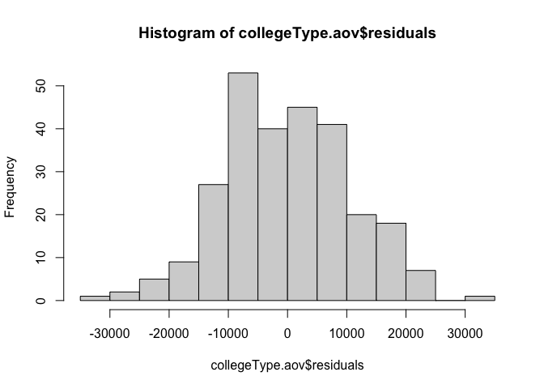

From the histogram above, we can see that the normality assumption seem to be met since the histogram roughly forms a bell curve, indicating that the residuals follow a normal distribution.

### Conclusion

Our p value of 2.2e-16 is much smaller than our significance level of .05. Therefore, we can reject our null hypothesis. There is evidence that graduates of at least one college type tend to have different mid career salaries than other college types.

## Analysis with Linear Models

### Model between the response and neither of the explanatory variables

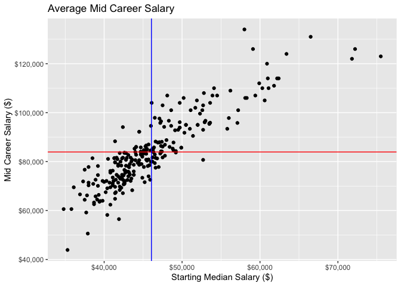

#### Description

First, we considered just the Mid career median salary, in order to see the average mid career median salary. In addition, we showed the average starting median salary on the graph to better visualize where the averages of the two variables meet. [^3]

**Model Equation:** Mid.Career.Salary = 83932.34

- **y-intercept:** The intercept for the response variable only is the same as the mean. The average mid career salary for college graduates is $83,932.32.
- **slope:** The slope is zero since this is simply a horizontal line